# Análise climática do estado de Sergipe

Laboratório de Estatística - Ivan Robert Enriquez Guzman

Elias Ribeiro Rosa Junior e Ornella Scardua Ferreira

Neste trabalho, uma análise de Séries Temporais será feita para avaliar a temperatura do estado de Sergipe com base em covariáveis tais quais: elevação atmosférica, precipitação, radiação, umidade, pressão atmosfésrica e velocidade do vento. A base de dados em análise contém 159.672 observações coletadas por hora da estação Alagoas, em Sergipe, no período de 2000 a 2021.

### Análise descritiva

Inicialmente, construímos uma tabela em que podem ser vistas as principais medidas-resumo e os histogramas das covariáveis, além de gráficos de *boxplot* que reforçam visualmente as informações contidas nessa tabela. A princípio, por meio das medidas e dos *boxplots*, podemos observar que as covariáveis elevação atmosférica, precipitação e radiação estão concentradas em um único intervalo de valores e que os dados associados às covariáveis umidade, pressão atmosférica, velocidade do vento e temperatura parecem estar dispersos em relação à média de maneira razoável. Já os histogramas sugerem distribuições assimétricas em todas covariáveis, embora pressão atmosférica e temperatura apontem para uma leve simetria em suas distribuições.

Tabela 1: Medidas resumo das covariáveis.

Unique (#)

Missing (%)

Mean

SD

Min

Median

Max

height

2

0

4.6

0.3

3.7

4.7

4.7

[figure not shown]

prcp

136

14

0.1

1.0

0.0

0.0

75.4

[figure not shown]

radiacao

5747

50

1903.1

4786.5

0.0

1096.5

47153.0

[figure not shown]

umidade

95

17

71.8

11.2

7.0

72.0

100.0

[figure not shown]

press_atm

21

9

1013.9

2.7

1004.0

1014.0

1023.0

[figure not shown]

vento_velo

92

16

2.9

1.6

0.0

2.9

10.8

[figure not shown]

temp

203

9

26.7

2.1

18.7

26.6

39.4

[figure not shown]

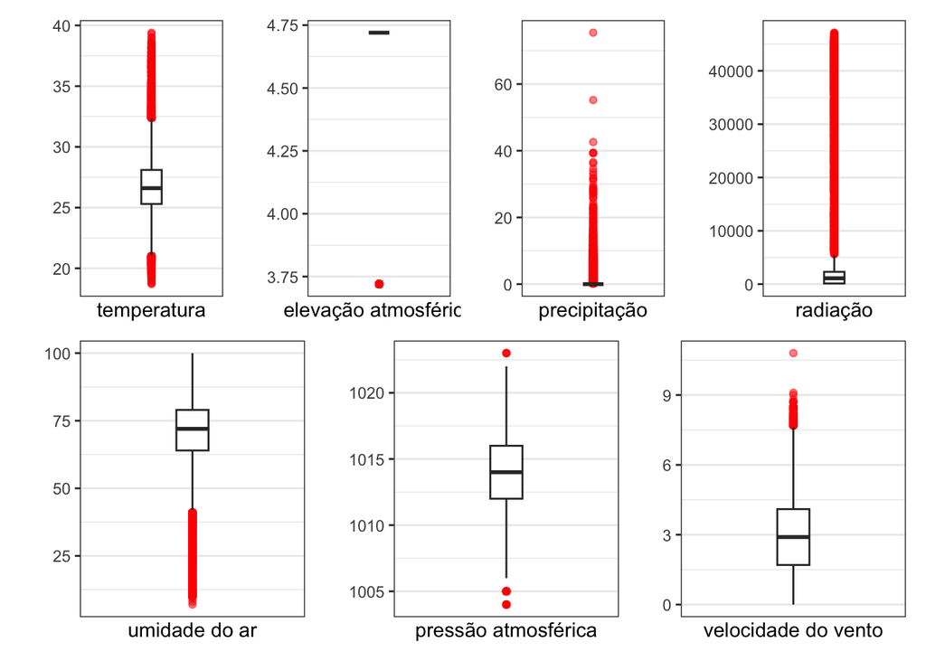

Figura 1: Boxplots das variáveis.

### Análise temporal univariada

Série estacionária com uma diferenciação, conforme gráfico da série a seguir.

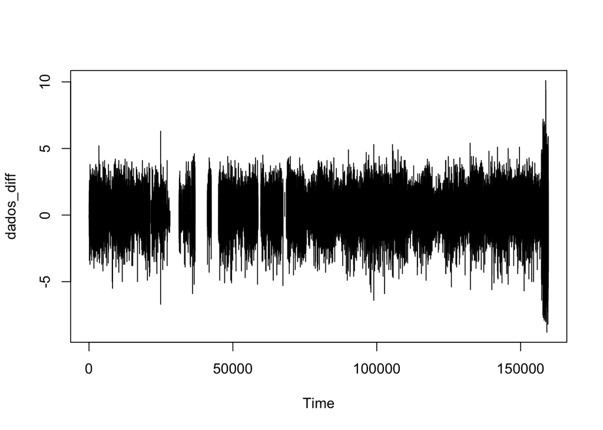

Gráficos ACF e PACF.

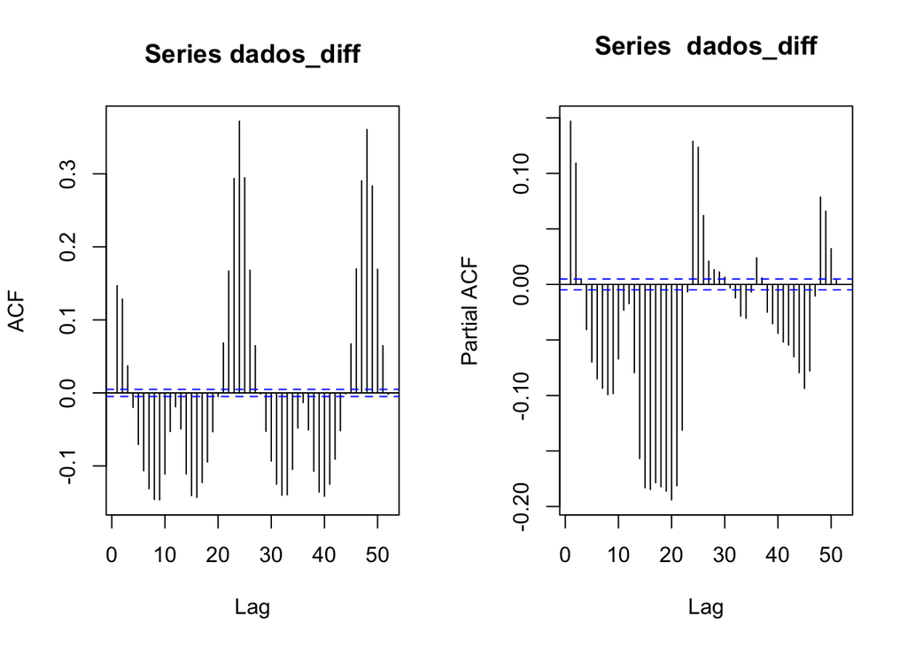

Ajuste.

```
## Series: s
## ARIMA(2,0,1) with non-zero mean
##
## Coefficients:
##          ar1      ar2      ma1     mean
##       1.6274  -0.8786  -0.6663  26.7131
## s.e.  0.0375   0.0343   0.0532   0.0482
##
## sigma^2 = 0.2707:  log likelihood = -157.74
## AIC=325.48   AICc=325.78   BIC=342.15
```

Previsão da temperatura. A previsão para a temperatura na cidade de Aracaju/SE segue a tendência sazonal dos últimos anos.

```
##     Point Forecast    Lo 80    Hi 80    Lo 95    Hi 95
## 208       27.03549 26.36869 27.70230 26.01571 28.05528
## 209       25.89591 24.97109 26.82074 24.48152 27.31031
## 210       25.10000 24.06841 26.13159 23.52232 26.67768
## 211       24.80594 23.75863 25.85325 23.20422 26.40766
## 212       25.02666 23.97386 26.07946 23.41655 26.63678
## 213       25.64420 24.53983 26.74857 23.95521 27.33319
## 214       26.45524 25.26329 27.64719 24.63231 28.27817
## 215       27.23255 25.96309 28.50200 25.29109 29.17401
## 216       27.78497 26.47659 29.09336 25.78397 29.78597
## 217       28.00105 26.68604 29.31606 25.98992 30.01218
```

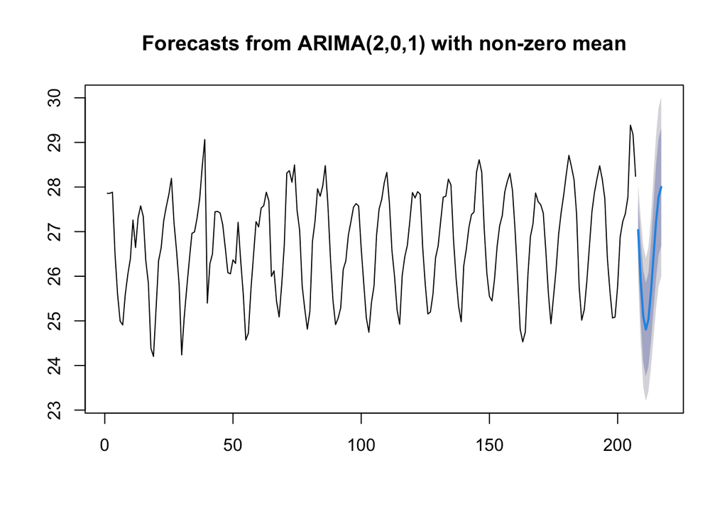

### Análise temporal multivariada

```
## [1] "A variável em análise é: height"
```

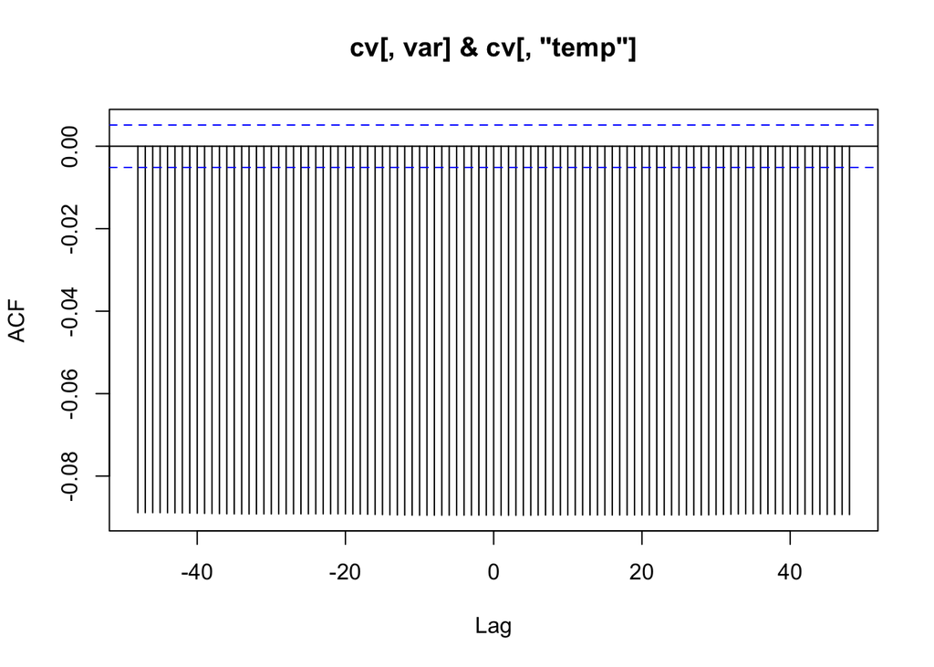

```
##
## Autocorrelations of series 'X', by lag
##
##    -48    -47    -46    -45    -44    -43    -42    -41    -40    -39    -38
## -0.089 -0.089 -0.089 -0.089 -0.089 -0.089 -0.089 -0.089 -0.089 -0.089 -0.089
##    -37    -36    -35    -34    -33    -32    -31    -30    -29    -28    -27
## -0.089 -0.089 -0.089 -0.089 -0.089 -0.089 -0.089 -0.089 -0.089 -0.089 -0.089
##    -26    -25    -24    -23    -22    -21    -20    -19    -18    -17    -16
## -0.089 -0.089 -0.089 -0.089 -0.089 -0.089 -0.089 -0.089 -0.089 -0.089 -0.089
##    -15    -14    -13    -12    -11    -10     -9     -8     -7     -6     -5
## -0.089 -0.089 -0.089 -0.089 -0.089 -0.089 -0.089 -0.089 -0.089 -0.089 -0.089
##     -4     -3     -2     -1      0      1      2      3      4      5      6
## -0.089 -0.089 -0.089 -0.089 -0.089 -0.089 -0.089 -0.090 -0.090 -0.089 -0.089
##      7      8      9     10     11     12     13     14     15     16     17
## -0.089 -0.089 -0.089 -0.089 -0.089 -0.089 -0.089 -0.089 -0.089 -0.089 -0.089
##     18     19     20     21     22     23     24     25     26     27     28
## -0.089 -0.089 -0.089 -0.089 -0.089 -0.089 -0.089 -0.089 -0.089 -0.089 -0.089
##     29     30     31     32     33     34     35     36     37     38     39
## -0.089 -0.089 -0.089 -0.089 -0.089 -0.089 -0.089 -0.089 -0.089 -0.089 -0.089
##     40     41     42     43     44     45     46     47     48
## -0.089 -0.089 -0.089 -0.089 -0.089 -0.089 -0.089 -0.089 -0.089
## [1] "A variável em análise é: prcp"
```

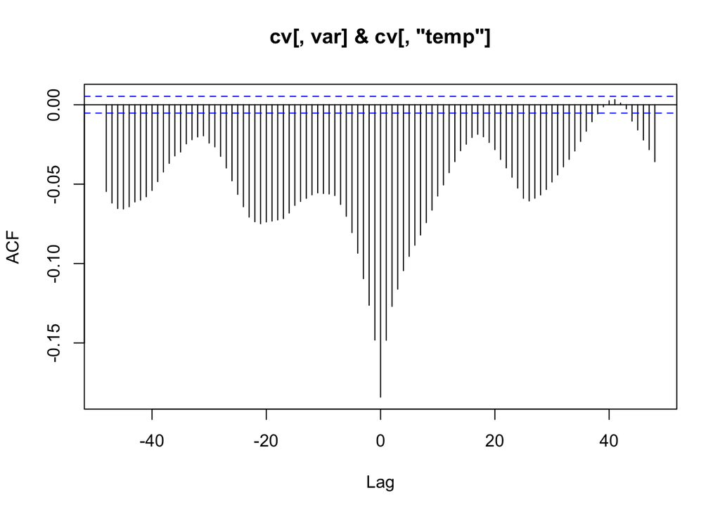

```
##
## Autocorrelations of series 'X', by lag
##
##    -48    -47    -46    -45    -44    -43    -42    -41    -40    -39    -38
## -0.055 -0.062 -0.065 -0.066 -0.064 -0.061 -0.060 -0.058 -0.054 -0.048 -0.042
##    -37    -36    -35    -34    -33    -32    -31    -30    -29    -28    -27
## -0.037 -0.032 -0.030 -0.025 -0.022 -0.020 -0.020 -0.024 -0.027 -0.032 -0.040
##    -26    -25    -24    -23    -22    -21    -20    -19    -18    -17    -16
## -0.048 -0.056 -0.064 -0.071 -0.074 -0.075 -0.074 -0.073 -0.073 -0.072 -0.068
##    -15    -14    -13    -12    -11    -10     -9     -8     -7     -6     -5
## -0.063 -0.061 -0.059 -0.057 -0.056 -0.056 -0.056 -0.057 -0.063 -0.070 -0.081
##     -4     -3     -2     -1      0      1      2      3      4      5      6
## -0.093 -0.109 -0.126 -0.148 -0.184 -0.148 -0.127 -0.116 -0.104 -0.095 -0.088
##      7      8      9     10     11     12     13     14     15     16     17
## -0.082 -0.074 -0.066 -0.057 -0.051 -0.043 -0.036 -0.029 -0.025 -0.021 -0.019
##     18     19     20     21     22     23     24     25     26     27     28
## -0.020 -0.024 -0.028 -0.034 -0.040 -0.046 -0.052 -0.059 -0.061 -0.059 -0.057
##     29     30     31     32     33     34     35     36     37     38     39
## -0.053 -0.049 -0.044 -0.039 -0.034 -0.029 -0.023 -0.017 -0.011 -0.006 -0.001
##     40     41     42     43     44     45     46     47     48
##  0.002  0.003  0.001 -0.003 -0.010 -0.016 -0.022 -0.028 -0.036
## [1] "A variável em análise é: radiacao"
```

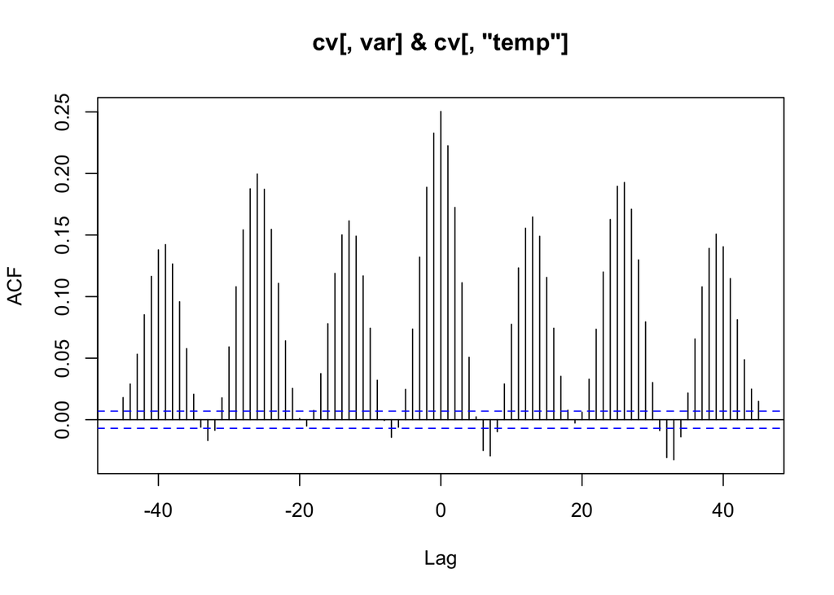

```
##
## Autocorrelations of series 'X', by lag
##
##    -45    -44    -43    -42    -41    -40    -39    -38    -37    -36    -35
##  0.018  0.029  0.053  0.085  0.116  0.138  0.142  0.126  0.096  0.058  0.021
##    -34    -33    -32    -31    -30    -29    -28    -27    -26    -25    -24
## -0.006 -0.017 -0.009  0.018  0.059  0.108  0.154  0.188  0.199  0.187  0.155
##    -23    -22    -21    -20    -19    -18    -17    -16    -15    -14    -13
##  0.111  0.064  0.025  0.001 -0.005  0.008  0.037  0.078  0.119  0.150  0.161
##    -12    -11    -10     -9     -8     -7     -6     -5     -4     -3     -2
##  0.149  0.117  0.074  0.032 -0.001 -0.014 -0.006  0.025  0.074  0.132  0.189
##     -1      0      1      2      3      4      5      6      7      8      9
##  0.233  0.250  0.222  0.172  0.111  0.051  0.002 -0.025 -0.029 -0.010  0.029
##     10     11     12     13     14     15     16     17     18     19     20
##  0.077  0.123  0.156  0.165  0.149  0.116  0.074  0.035  0.008 -0.003  0.006
##     21     22     23     24     25     26     27     28     29     30     31
##  0.033  0.073  0.120  0.163  0.190  0.193  0.171  0.130  0.079  0.030 -0.009
##     32     33     34     35     36     37     38     39     40     41     42
## -0.031 -0.032 -0.014  0.022  0.066  0.108  0.139  0.151  0.140  0.115  0.081
##     43     44     45
##  0.049  0.025  0.015
## [1] "A variável em análise é: umidade"
```

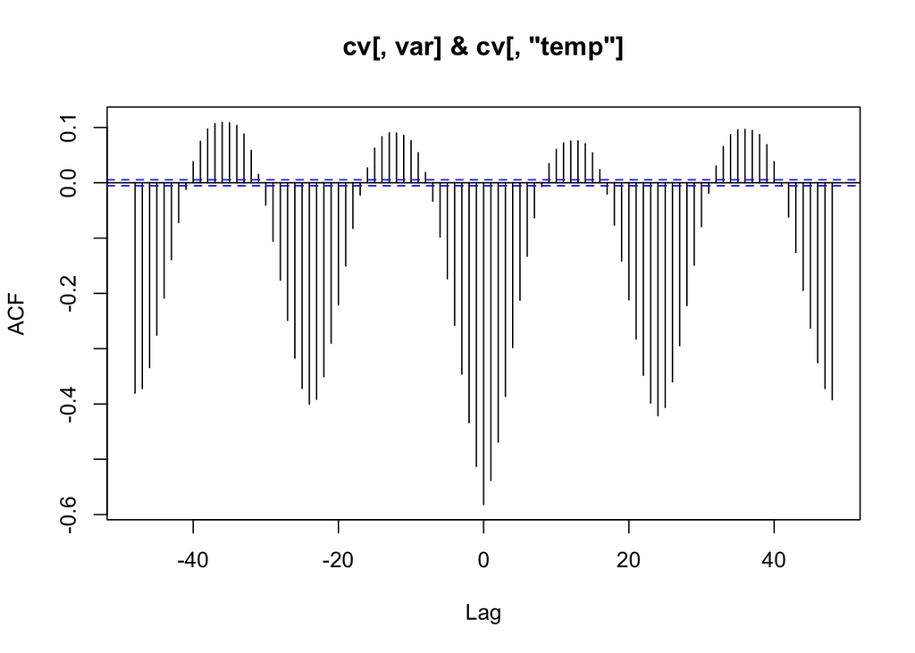

```
##
## Autocorrelations of series 'X', by lag
##
##    -48    -47    -46    -45    -44    -43    -42    -41    -40    -39    -38
## -0.380 -0.372 -0.334 -0.276 -0.209 -0.139 -0.072 -0.012  0.038  0.075  0.097
##    -37    -36    -35    -34    -33    -32    -31    -30    -29    -28    -27
##  0.107  0.109  0.109  0.104  0.088  0.058  0.015 -0.041 -0.106 -0.176 -0.249
##    -26    -25    -24    -23    -22    -21    -20    -19    -18    -17    -16
## -0.317 -0.372 -0.400 -0.392 -0.351 -0.290 -0.221 -0.150 -0.083 -0.022  0.027
##    -15    -14    -13    -12    -11    -10     -9     -8     -7     -6     -5
##  0.063  0.084  0.091  0.090  0.086  0.076  0.055  0.018 -0.033 -0.098 -0.174
##     -4     -3     -2     -1      0      1      2      3      4      5      6
## -0.258 -0.346 -0.434 -0.513 -0.582 -0.538 -0.469 -0.386 -0.298 -0.212 -0.133
##      7      8      9     10     11     12     13     14     15     16     17
## -0.063 -0.007  0.035  0.061  0.072  0.075  0.076  0.071  0.054  0.024 -0.021
##     18     19     20     21     22     23     24     25     26     27     28
## -0.077 -0.142 -0.212 -0.283 -0.348 -0.398 -0.421 -0.406 -0.360 -0.294 -0.222
##     29     30     31     32     33     34     35     36     37     38     39
## -0.149 -0.079 -0.019  0.030  0.066  0.087  0.096  0.097  0.095  0.087  0.069
##     40     41     42     43     44     45     46     47     48
##  0.038 -0.006 -0.062 -0.126 -0.195 -0.263 -0.325 -0.372 -0.392
## [1] "A variável em análise é: press_atm"
```

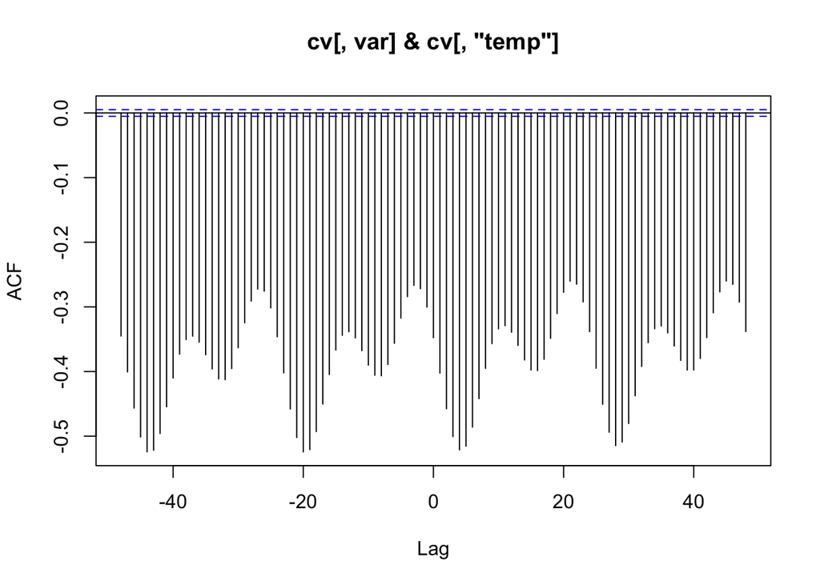

```
##
## Autocorrelations of series 'X', by lag
##
##    -48    -47    -46    -45    -44    -43    -42    -41    -40    -39    -38
## -0.345 -0.401 -0.457 -0.501 -0.524 -0.522 -0.496 -0.455 -0.410 -0.373 -0.351
##    -37    -36    -35    -34    -33    -32    -31    -30    -29    -28    -27
## -0.345 -0.355 -0.374 -0.396 -0.412 -0.413 -0.395 -0.363 -0.325 -0.291 -0.273
##    -26    -25    -24    -23    -22    -21    -20    -19    -18    -17    -16
## -0.276 -0.302 -0.346 -0.402 -0.458 -0.502 -0.524 -0.521 -0.493 -0.450 -0.405
##    -15    -14    -13    -12    -11    -10     -9     -8     -7     -6     -5
## -0.367 -0.344 -0.338 -0.348 -0.368 -0.390 -0.406 -0.407 -0.389 -0.356 -0.317
##     -4     -3     -2     -1      0      1      2      3      4      5      6
## -0.284 -0.267 -0.272 -0.300 -0.348 -0.402 -0.458 -0.501 -0.521 -0.515 -0.486
##      7      8      9     10     11     12     13     14     15     16     17
## -0.442 -0.395 -0.357 -0.334 -0.329 -0.339 -0.360 -0.382 -0.398 -0.399 -0.381
##     18     19     20     21     22     23     24     25     26     27     28
## -0.349 -0.310 -0.277 -0.260 -0.265 -0.292 -0.338 -0.395 -0.451 -0.494 -0.515
##     29     30     31     32     33     34     35     36     37     38     39
## -0.509 -0.480 -0.438 -0.392 -0.355 -0.334 -0.330 -0.340 -0.360 -0.383 -0.398
##     40     41     42     43     44     45     46     47     48
## -0.398 -0.380 -0.347 -0.309 -0.277 -0.260 -0.265 -0.293 -0.338
## [1] "A variável em análise é: vento_velo"
```

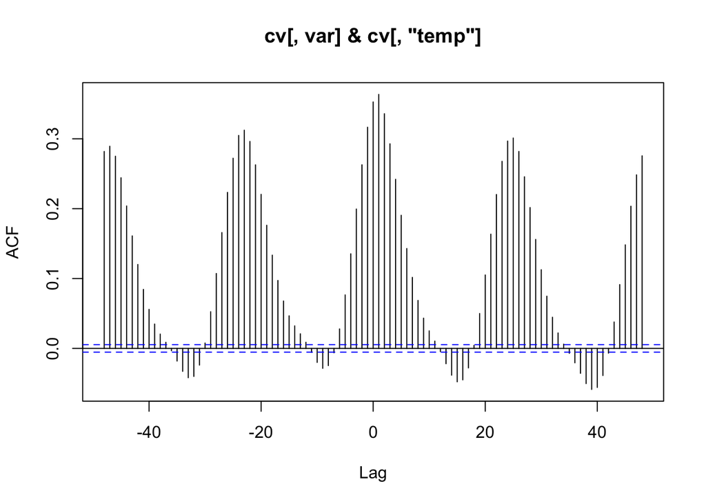

```
##
## Autocorrelations of series 'X', by lag
##
##    -48    -47    -46    -45    -44    -43    -42    -41    -40    -39    -38
##  0.282  0.289  0.275  0.244  0.204  0.161  0.120  0.084  0.056  0.035  0.020
##    -37    -36    -35    -34    -33    -32    -31    -30    -29    -28    -27
##  0.009 -0.003 -0.018 -0.033 -0.042 -0.040 -0.024  0.008  0.052  0.107  0.166
##    -26    -25    -24    -23    -22    -21    -20    -19    -18    -17    -16
##  0.223  0.272  0.305  0.312  0.296  0.263  0.220  0.176  0.133  0.097  0.068
##    -15    -14    -13    -12    -11    -10     -9     -8     -7     -6     -5
##  0.047  0.032  0.021  0.009 -0.006 -0.020 -0.029 -0.025 -0.006  0.028  0.077
##     -4     -3     -2     -1      0      1      2      3      4      5      6
##  0.135  0.199  0.263  0.317  0.353  0.364  0.336  0.293  0.242  0.191  0.143
##      7      8      9     10     11     12     13     14     15     16     17
##  0.102  0.069  0.043  0.025  0.010 -0.005 -0.022 -0.038 -0.048 -0.045 -0.028
##     18     19     20     21     22     23     24     25     26     27     28
##  0.004  0.050  0.105  0.163  0.220  0.268  0.297  0.301  0.282  0.246  0.202
##     29     30     31     32     33     34     35     36     37     38     39
##  0.156  0.113  0.075  0.045  0.022  0.006 -0.007 -0.021 -0.036 -0.050 -0.059
##     40     41     42     43     44     45     46     47     48
## -0.056 -0.039 -0.007  0.038  0.091  0.148  0.203  0.248  0.276
```

Dados faltantes nas covariáveis precipitação, umidade e velocidade do vento.

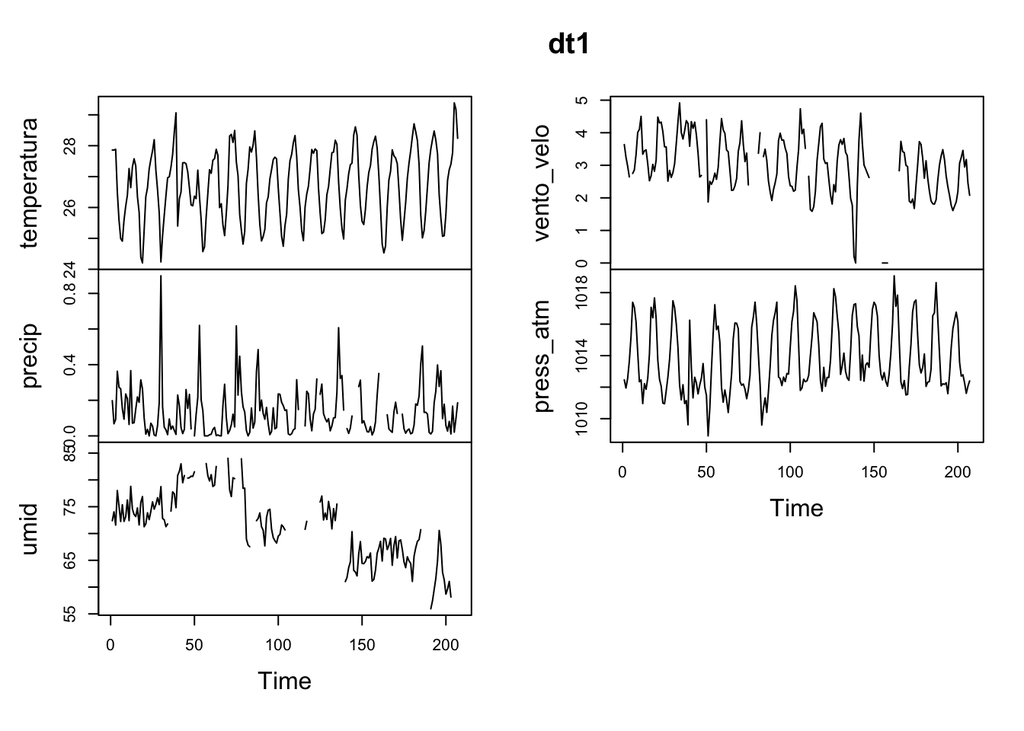

Inputação de dados por interpolação linear.

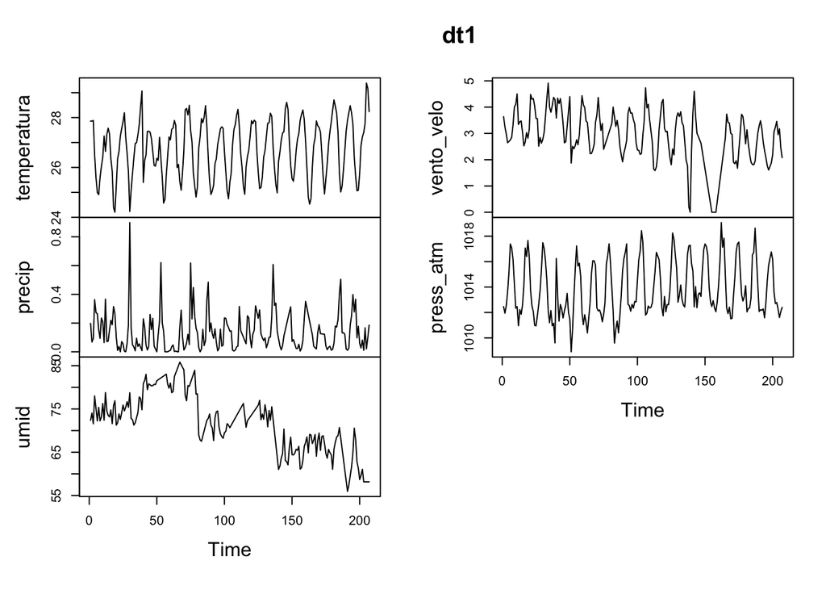

Séries temporais das variáveis aparentemente estacionárias.

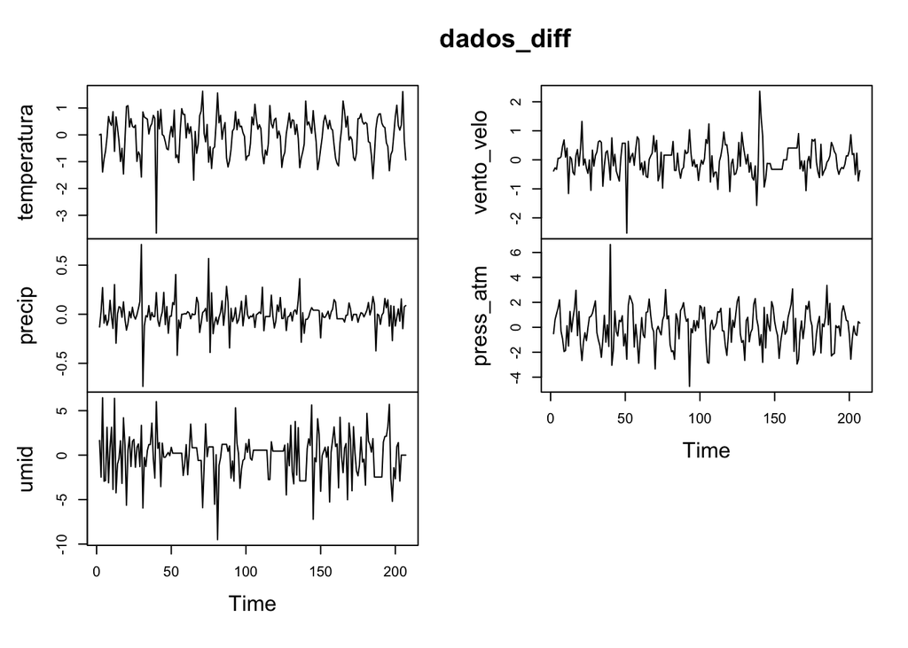

Gráfico ACF da série.

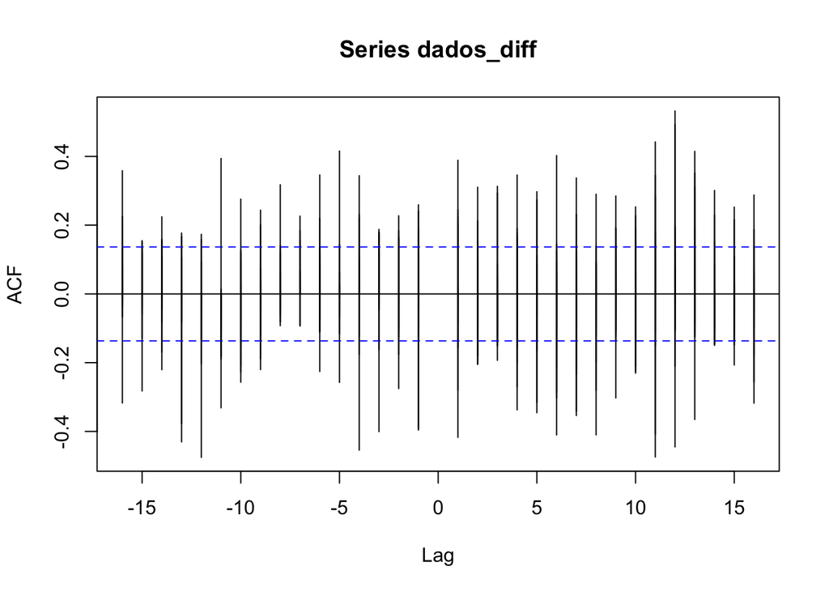

Correlação cruzada extendida para identificar ordens $p$ e $q$.

_*p: número de observações de defasagem incluídas no modelo, também conhecido como ordem de defasagem_ _*d: grau de diferenciação_ _*q: ordem da média móvel_

```
## p-values table of Extended Cross-correlation Matrices:
## Column: MA order
## Row   : AR order
##        0      1      2      3      4      5      6
## 0 0.0000 0.0000 0.0000 0.0000 0.0000 0.0000 0.0000
## 1 0.0000 0.1228 0.1084 0.2509 0.0852 0.5942 0.9935
## 2 0.0016 0.4738 0.3548 0.5955 0.6609 0.8684 0.9857
## 3 0.6314 0.8855 0.9667 0.9556 0.9833 0.5566 0.9448
## 4 0.9986 1.0000 0.9997 1.0000 0.9916 0.7085 0.9945
## 5 1.0000 1.0000 1.0000 1.0000 0.9999 0.9986 0.9987
```

Ajuste do modelo VARMA(p=0,q=2).

```
## Number of parameters:  55
## initial estimates:  0.0071 -2e-04 -0.097 -0.0073 0.0059 -0.3023 -0.1466 -0.0198 -0.0991 -0.0737 -0.352 -0.7317 -0.0082 0.1079 -0.006 0.0703 -0.5611 0.005 0.0078 0.011 0.0101 -0.068 -0.0061 -0.043 -0.0193 0.2229 -2.9121 -0.1237 0.7771 0.246 0.5787 0.6275 0.0533 0.0163 0.2053 -0.2072 -0.2866 -0.025…
## Par. lower-bounds:  -0.0957 -0.0176 -0.4281 -0.0849 -0.2013 -0.6996 -1.3064 -0.087 -0.3724 -0.2138 -0.7493 -1.898 -0.0746 -0.1638 -0.1459 0.0028 -0.7582 -0.0065 -0.0386 -0.0128 -0.0574 -0.2663 -0.0174 -0.0892 -0.0431 -1.0559 -6.6451 -0.3401 -0.1026 -0.2049 -0.7002 -3.1265 -0.1605 -0.8583 -0.2449 …
## Par. upper-bounds:  0.11 0.0173 0.2341 0.0702 0.213 0.095 1.0132 0.0475 0.1742 0.0664 0.0454 0.4346 0.0583 0.3796 0.1338 0.1379 -0.3639 0.0164 0.0543 0.0349 0.0777 0.1302 0.0052 0.0032 0.0045 1.5018 0.8208 0.0926 1.6567 0.6968 1.8576 4.3815 0.2671 0.8909 0.6554 0.0925 0.588 0.0255 0.2217 0.1323 0…
## Final   Estimates:  0.01426852 0.009773574 -0.1982365 -0.004956556 -0.04127747 -0.0324227 -0.1404545 -0.05958596 -0.04619905 0.06637601 -0.09121771 -0.7171012 -0.002798678 0.1307754 0.04700563 0.05945826 -0.3639321 0.005383882 0.008701071 0.03485303 -0.05713017 0.03678162 -0.01269909 -0.02137761 …
##
## Coefficient(s):
##               Estimate  Std. Error    t value Pr(>|t|)
## temperatura  1.427e-02   3.278e-04  4.352e+01   <2e-16 ***
## precip       9.774e-03   1.681e-04  5.814e+01   <2e-16 ***
## umid        -1.982e-01         NaN        NaN      NaN
## vento_velo  -4.957e-03   9.453e-05 -5.244e+01   <2e-16 ***
## press_atm   -4.128e-02   1.053e-03 -3.921e+01   <2e-16 ***
##             -3.242e-02         NaN        NaN      NaN
##             -1.405e-01         NaN        NaN      NaN
##             -5.959e-02   1.704e-03 -3.498e+01   <2e-16 ***
##             -4.620e-02   7.564e-04 -6.108e+01   <2e-16 ***
##              6.638e-02   1.618e-03  4.103e+01   <2e-16 ***
##             -9.122e-02   1.084e-03 -8.413e+01   <2e-16 ***
##             -7.171e-01   1.086e-02 -6.600e+01   <2e-16 ***
##             -2.799e-03   2.699e-05 -1.037e+02   <2e-16 ***
##              1.308e-01   1.897e-03  6.895e+01   <2e-16 ***
##              4.701e-02         NaN        NaN      NaN
##              5.946e-02         NaN        NaN      NaN
##             -3.639e-01         NaN        NaN      NaN
##              5.384e-03         NaN        NaN      NaN
##              8.701e-03   1.306e-04  6.663e+01   <2e-16 ***
##              3.485e-02         NaN        NaN      NaN
##             -5.713e-02         NaN        NaN      NaN
##              3.678e-02   1.593e-03  2.309e+01   <2e-16 ***
##             -1.270e-02         NaN        NaN      NaN
##             -2.138e-02         NaN        NaN      NaN
##             -4.010e-03   7.551e-05 -5.310e+01   <2e-16 ***
##              3.451e-01         NaN        NaN      NaN
##             -2.830e+00         NaN        NaN      NaN
##             -1.478e-01   1.145e-10 -1.291e+09   <2e-16 ***
##              4.751e-01         NaN        NaN      NaN
##              3.625e-01   3.599e-03  1.007e+02   <2e-16 ***
##              5.100e-01   4.229e-03  1.206e+02   <2e-16 ***
##              6.203e-01   1.969e-02  3.150e+01   <2e-16 ***
```

[output cut: 40 more lines]

```
## [2,]  0.05713 -0.0368  0.0127  0.0214  0.00401
## [3,] -0.51001 -0.6203 -0.0694 -0.0192 -0.22571
## [4,]  0.00725 -0.0663 -0.0182  0.1557  0.01475
## [5,] -0.07404 -1.3325  0.0419 -0.1252  0.16990
##
## Residuals cov-matrix:
##             [,1]        [,2]       [,3]        [,4]        [,5]
## [1,]  0.50249555 -0.02888219 -0.5410700  0.15291892 -0.73149055
## [2,] -0.02888219  0.02653915  0.1956105 -0.02902833  0.01524131
## [3,] -0.54106999  0.19561046  6.7598751 -0.29283648 -0.19892784
## [4,]  0.15291892 -0.02902833 -0.2928365  0.29805018 -0.23074350
## [5,] -0.73149055  0.01524131 -0.1989278 -0.23074350  2.20842002
## ----
## aic=  -3.686477
## bic=  -2.797966
```

```
##           Length Class  Mode
## data      1030   mts    numeric
## ARorder      1   -none- numeric
## MAorder      1   -none- numeric
## cnst         1   -none- logical
## coef        55   -none- numeric
## secoef      55   -none- numeric
## residuals 1020   -none- numeric
## Sigma       25   -none- numeric
## aic          1   -none- numeric
## bic          1   -none- numeric
## Phi          0   -none- NULL
## Theta       50   -none- numeric
## Ph0          5   -none- numeric
```

Análise diagnóstico.

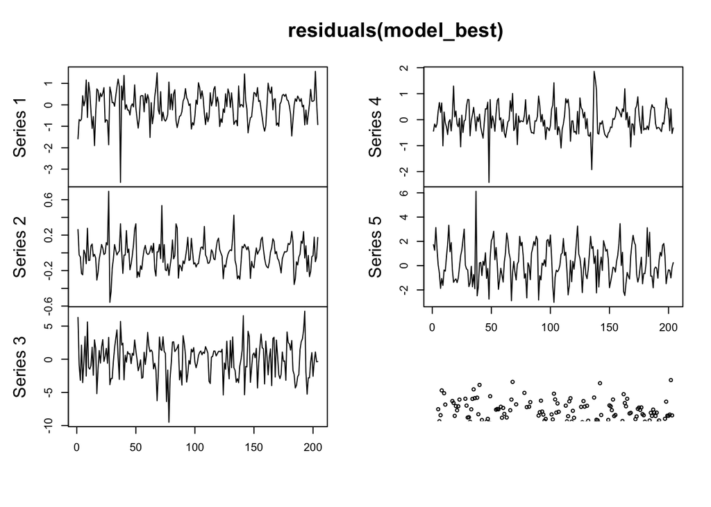

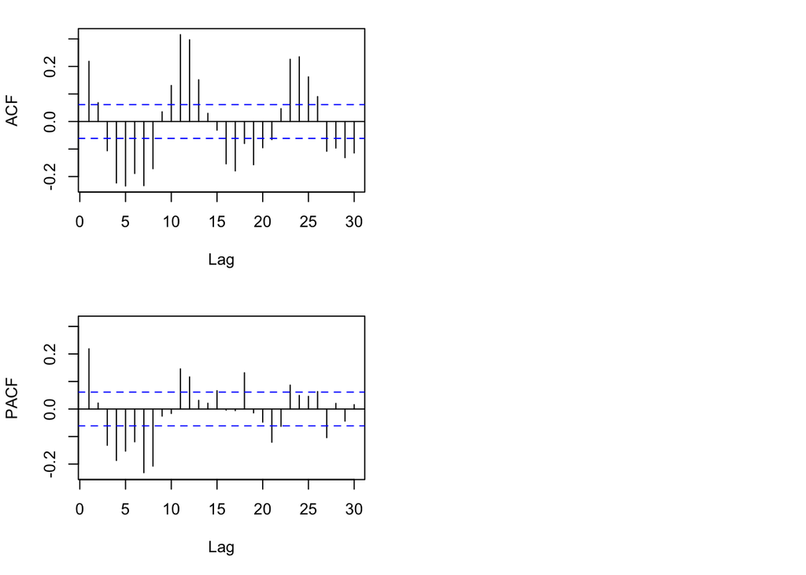

Predições.

```
## Predictions at origin  206
##      temperatura    precip    umid vento_velo press_atm
##          0.01293 -0.099499 -1.0199   0.186628  -0.09244
##         -0.05523  0.078998 -0.5346   0.053122   0.05380
## fcst     0.01427  0.009774 -0.1982  -0.004957  -0.04128
## fcst     0.01427  0.009774 -0.1982  -0.004957  -0.04128
## fcst     0.01427  0.009774 -0.1982  -0.004957  -0.04128
## fcst     0.01427  0.009774 -0.1982  -0.004957  -0.04128
## fcst     0.01427  0.009774 -0.1982  -0.004957  -0.04128
## fcst     0.01427  0.009774 -0.1982  -0.004957  -0.04128
## fcst     0.01427  0.009774 -0.1982  -0.004957  -0.04128
## fcst     0.01427  0.009774 -0.1982  -0.004957  -0.04128
## fcst     0.01427  0.009774 -0.1982  -0.004957  -0.04128
## fcst     0.01427  0.009774 -0.1982  -0.004957  -0.04128
## fcst     0.01427  0.009774 -0.1982  -0.004957  -0.04128
## fcst     0.01427  0.009774 -0.1982  -0.004957  -0.04128
## fcst     0.01427  0.009774 -0.1982  -0.004957  -0.04128
## fcst     0.01427  0.009774 -0.1982  -0.004957  -0.04128
## fcst     0.01427  0.009774 -0.1982  -0.004957  -0.04128
## fcst     0.01427  0.009774 -0.1982  -0.004957  -0.04128
## fcst     0.01427  0.009774 -0.1982  -0.004957  -0.04128
## fcst     0.01427  0.009774 -0.1982  -0.004957  -0.04128
## Standard errors of predictions
##         [,1]   [,2]  [,3]   [,4]  [,5]
##  [1,] 0.7089 0.1629 2.600 0.5459 1.486
##  [2,] 0.7370 0.1776 2.777 0.5677 1.603
##  [3,] 0.7565 0.1830 2.790 0.5784 1.641
##  [4,] 0.7565 0.1830 2.790 0.5784 1.641
##  [5,] 0.7565 0.1830 2.790 0.5784 1.641
##  [6,] 0.7565 0.1830 2.790 0.5784 1.641
##  [7,] 0.7565 0.1830 2.790 0.5784 1.641
##  [8,] 0.7565 0.1830 2.790 0.5784 1.641
##  [9,] 0.7565 0.1830 2.790 0.5784 1.641
## [10,] 0.7565 0.1830 2.790 0.5784 1.641
## [11,] 0.7565 0.1830 2.790 0.5784 1.641
## [12,] 0.7565 0.1830 2.790 0.5784 1.641
## [13,] 0.7565 0.1830 2.790 0.5784 1.641
## [14,] 0.7565 0.1830 2.790 0.5784 1.641
## [15,] 0.7565 0.1830 2.790 0.5784 1.641
## [16,] 0.7565 0.1830 2.790 0.5784 1.641
## [17,] 0.7565 0.1830 2.790 0.5784 1.641
## [18,] 0.7565 0.1830 2.790 0.5784 1.641
## [19,] 0.7565 0.1830 2.790 0.5784 1.641
## [20,] 0.7565 0.1830 2.790 0.5784 1.641
```